**INTRODUCTION TO ARTIFICIAL INTELLIGENCE**  
Academiejaar 2021-2022  
Stefaan Haspeslagh  
Andy Louwyck  
Pieter Ideler

# Maze

## Inleiding

Het doolhofprobleem is een veel gebruikt probleem om zoekalgoritmen op uit te testen. In deze oefening stellen we een doolhof voor als een rooster met n rijen en n kolommen. We hebben in totaal dus n x n vakken. Een vak kan een barrière bevatten, dit zijn vakjes waarop niet kan 'gewandeld' worden.

De uitdaging is om, gegeven een startpositie (links onder in het voorbeeld), een pad naar het doel te vinden (rechts boven in het voorbeeld). De mogelijke richtingen waarin gewandeld kan worden (in die volgorde!) zijn: links, rechts, naar boven en naar onder. Diagonaal kan er niet gewandeld worden. Dit zijn hier onze **production rules**, die we gaan toepassen op onze huidige toestand of **state** om te weten welke vakjes we in een volgende stap kunnen nemen. Om die volgende zetten of **moves** te kunnen bepalen, moeten we naast de production rules de volgende zaken kennen:

- de *positie* wat het vakje is waar we staan;
- de *configuratie* van het doolhof;
- het *pad* dat we al hebben afgelegd.

Het eerste punt is evident, het tweede is nodig omdat we moeten weten waar de barrières en randen zijn, en het laatste punt is nodig omdat we niet op onze stappen willen terugkeren. Als we alle mogelijke moves hebben berekend, dan kiezen we er één uit en gaan zo één vakje verder, waardoor we in een nieuwe toestand komen. De keuze van die move hangt af van het zoekalgoritme dat we gaan toepassen. Daar gaan we in de volgende topics dieper op in gaan. In deze notebook maken we een implementatie van de **state-space** en de production rules voor het doolhofprobleem. De state-space is de verzameling van alle mogelijke toestanden van het zoekprobleem.

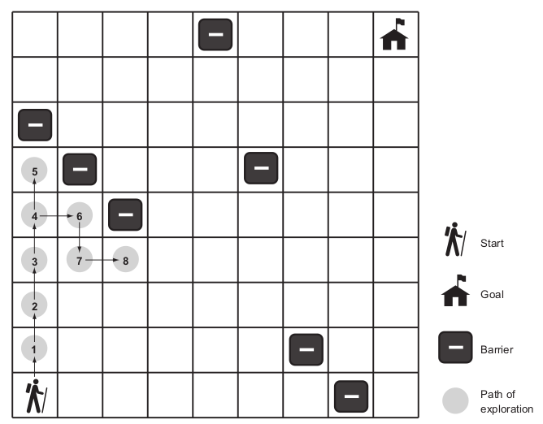

## Positie

In het doolhof moeten we dus eerst en vooral de verschillende vakjes of posities kunnen aanduiden. Daarvoor definiëren we een klasse `Position` die een (irow, icol)-coördinaat in het doolhof voorstelt. De coördinaat links boven is (0, 0).

```python
class Position:

    def __init__(self, irow, icol):
        self.irow = irow
        self.icol = icol

    def __eq__(self, other):
        return self.irow == other.irow and self.icol == other.icol

    def __repr__(self):
        return "({}, {})".format(self.irow, self.icol)
```

Methode `__init__` kunnen we zien als de constructor van de klasse (ook al is het in principe geen echte constructor). We willen ook nagaan of twee posities al dan niet gelijk zijn, en daarom overschrijven we de "equality" methode `__eq__`, die de gelijkheidsoperator `==` overschrijft. Deze methode retourneert `True` als de coördinaten van twee posities gelijk zijn, en `False` als dat niet zo is. Methode `__repr__` is de methode die een object van die klasse als string weergeeft. We overschrijven ook die methode zodat de coördinaat wordt weergegeven.

Stel nu dat we de positie op het vakje in rij 1 en kolom 2 willen opslaan, dan instantiëren we een `Position` object met coördinaten `irow=1` en `icol=2`. We kennen het object toe aan variabele `p1`:

```python
p1 = Position(irow=1, icol=2)  # parameternamen irow en icol mag je weglaten als de juiste volgorde wordt gerespecteerd
p1
```

```
(1, 2)
```

We definiëren een tweede positie met coördinaat (2, 2). We instantiëren een nieuw `Position` object en kennen het toe aan variabele `p2`:

```python
p2 = Position(2, 2)
p2
```

```
(2, 2)
```

We checken nu of de twee posities gelijk zijn aan elkaar, wat niet het geval is, dus moeten we `False` krijgen:

```python
p1 == p2
```

```
False
```

Als we controleren of ze niet aan elkaar gelijk zijn, dan krijgen we uiteraard `True`:

```python
p1 != p2
```

```
True
```

## Pad

We moeten ook het reeds afgelegde pad kunnen bijhouden, en dus definiëren we een klasse `Path`. Dat pad bestaat uit een reeks van opeenvolgende posities, die we meegeven met de constructor, die op zijn beurt de reeks toekent aan attribuut `positions`. We definiëren ook een property `length` die de padlengte geeft, en properties `irow` en `icol` die de coördinaten als NumPy array geven. Een NumPy array is net als een list, maar bedoeld voor numerieke elementen, waarop je dan allerhande matrixbewerkingen kan uitvoeren. We voorzien ook nog een methode `contains` die checkt of een gegeven positie al dan niet tot het pad behoort, en een methode `add` die een nieuwe positie aan het pad toevoegt en een nieuw `Path` object retourneert met het nieuwe pad. Tot slot overschrijven we opnieuw de `__repr__` methode om het pad mooi weer te geven als string.

```python
import numpy as np

class Path:

    def __init__(self, *positions):
        self.positions = positions

    @property
    def length(self):
        return len(self.positions)

    @property
    def irow(self):
        return np.array([position.irow for position in self.positions])

    @property
    def icol(self):
        return np.array([position.icol for position in self.positions])

    def contains(self, position):
        return position in self.positions

    def add(self, position):
        return Path(*self.positions, position)

    def __repr__(self):
        positions = ", ".join([str(position) for position in self.positions])
        return f"[{positions}]"
```

We definiëren een pad met posities (2, 2) en (3, 2). We instantiëren daarvoor een `Path` object die de twee `Position` objecten mee krijgt als afzonderlijk input argument. Het `Path` object stoppen we in variabele `path`:

```python
path = Path(Position(2, 2), Position(3, 2))
path
```

```
[(2, 2), (3, 2)]
```

We vragen de lengte op van het pad:

```python
path.length
```

```
2
```

En we we checken de coördinaten:

```python
path.irow, path.icol
```

```
(array([2, 3]), array([2, 2]))
```

Behoren onze posities `p1` en `p2` tot `path`?

```python
print(path.contains(p1))
print(path.contains(p2))
```

```
False
True
```

Tenslotte creëren we een nieuw pad door positie (4, 2) toe te voegen aan `path`:

```python
new_path = path.add(Position(4, 2))
new_path
```

```
[(2, 2), (3, 2), (4, 2)]
```

## Doolhof

Vervolgens moeten we ook de doolhofconfiguratie implementeren. We definiëren hiervoor een klasse `Maze` die een doolhof als een vierkant rooster voorstelt met n x n vakken. Het aantal vakken `n` wordt in attribuut `size` opgeslagen. Het rooster wordt gedefinieerd a.d.h.v. een 2D NumPy array, die in attribuut `grid` wordt opgeslagen, en als elementen integers bevat met de volgende code:

- 0: startvakje
- 1: vrij vakje
- 2: vakje met barrière
- 3: eindvakje

De `grid` array wordt aan de constructor meegegeven. Om ons het leven wat makkelijker te maken, definiëren we een statische methode `create` die een `maze` list van strings bevat met de volgende symbolen:

- `'*'`: startvakje
- `'.'`: vrij vakje
- `'#'`: vakje met barrière
- `'o'`: eindvakje

De methode zet de list van strings om naar een `grid` array, instantieert een nieuw `Maze` object, en retourneert dit. De `__repr__` methode die we opnieuw overschrijven, retourneert trouwens een string die de doolhofconfiguratie met dezelfde symbolen.

We definiëren verder nog methoden `get_start` en `get_goal` die de start- en eindposities retourneren als `Position` objecten. De methode `is_valid` checkt of een gegeven positie al dan niet geldig is. Een positie is niet geldig als het buiten het rooster valt of naar een vakje verwijst met een barrière. Tenslotte is er nog een `plot` methode waarmee we het doolhof kunnen plotten. Hiervoor maken we gebruik van de MatPlotLib library.

```python
import matplotlib.pyplot as plt
from matplotlib import colors

class Maze:

    symbols = ('*', '.', '#', 'o')

    def __init__(self, grid):
        # grid is integer array:
        # start = 0, free = 1, wall = 2, goal = 3
        self.grid = np.array(grid)
        self.size = self.grid.shape[0]

    def get_start(self):
        irow, icol = np.where(self.grid == 0)
        return Position(irow[0], icol[0])

    def get_goal(self):
        irow, icol = np.where(self.grid == 3)
        return Position(irow[0], icol[0])

    def is_valid(self, position):
        # checkt of een positie geldig is: moet binnen het grid liggen en mag geen barrière zijn
        return (0 <= position.irow < self.size and
                0 <= position.icol < self.size and
                self.grid[position.irow, position.icol] != 2)

    def plot(self):
        # colormap
        cmap = colors.ListedColormap(['forestgreen', 'lightyellow', 'purple', 'red'])
        bounds = np.linspace(-0.5, 3.5, 5)
        norm = colors.BoundaryNorm(bounds, cmap.N)
        # plot grid
        plt.matshow(self.grid, cmap=cmap, norm=norm)
        # axes
        xmax = self.size - 0.5
        ymax = self.size - 0.5
        ax = plt.gca()
        ax.set_aspect("equal")
        ax.set_xticks(np.linspace(-0.5, xmax, self.size + 1))
        ax.set_xticklabels([])
        ax.set_yticks(np.linspace(-0.5, ymax, self.size + 1))
        ax.set_yticklabels([])
        ax.tick_params(axis=u'both', which=u'both', length=0)
        # plot grid and set axis limits
        plt.grid()
        plt.xlim([-0.5, xmax])
        plt.ylim([ymax, -0.5])

    def __repr__(self):
        return "\n".join([''.join([self.symbols[item] for item in row]) for row in self.grid])

    @staticmethod
    def create(maze):
        # creëert grid adhv list van strings "maze"
        return Maze(grid=[[Maze.symbols.index(symbol) for symbol in row] for row in maze])
```

We creëren nu het volgende doolhof aan de hand van de statische methode `create`:

```
['o....',
 '.###.',
 '.#*#.',
 '.#...',
 '.....']
```

We kennen het gecreëerde `Maze` object toe aan variabele `maze`:

```python
maze = Maze.create(["o....",
                    ".###.",
                    ".#*#.",
                    ".#...",
                    "....."])
maze
```

```
o....
.###.
.#*#.
.#...
.....
```

We checken de start- en eindpositie:

```python
print("start:", maze.get_start())
print("doel:", maze.get_goal())
```

```
start: (2, 2)
doel: (0, 0)
```

En we plotten het doolhof:

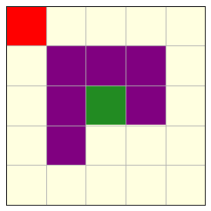

```python
maze.plot()
```

Kunnen we op het vakje (1, 2) staan?

```python
maze.is_valid(Position(1, 2))
```

```
False
```

## State-space OO-model

Voor we verder gaan implementeren we eerst een OO-model waarin de volgende concepten een plaats krijgen:

- **state**: een klasse waarin je de toestand van het zoekprobleem kan weergeven. Op een toestand moet je een move kunnen toepassen om naar een andere toestand te gaan.
- **goal**: van een bepaalde state moet je kunnen evalueren of die in de goaltoestand is of niet.
- **move**: een move bepaalt hoe je van de ene naar de andere toestand kan overgaan

Deze OO-structuur biedt een generiek kader waarin we de zoekproblemen kunnen formuleren. Na het implementeren van dit generieke kader, wordt een specifieke implementatie voor het doolhofprobleem opgesteld.

We starten met de abstracte klasse `State`. Voor een bepaalde state moeten we de mogelijke moves kunnen berekenen, kunnen bepalen of het al dan niet om de eindtoestand gaat, en een move kunnen toepassen. Voor elk van die 3 acties definiëren we een abstracte methode die dan voor het oplossen van een specifiek probleem via overerving zal moeten geïmplementeerd worden.

```python
from abc import ABC, abstractmethod

class State(ABC):

    @abstractmethod
    def calculate_moves(self):
        # Op een state wordt deze methode aangeroepen om volgens de production rules
        # de moves te berekenen die het probleem in een nieuwe toestand kunnen brengen.
        # Deze functie geeft dus een lijst van moves terug (eventueel leeg).
        pass

    @abstractmethod
    def apply_move(self, move):
        # Op een state kan een move toegepast worden om naar een volgende state over te gaan.
        # Deze functie geeft dus een nieuwe state terug.
        pass

    @abstractmethod
    def is_goal(self):
        # Controleert of een state de `goal state` is.
        # Retourneert dus een booleaanse waarde.
        pass
```

En dan hebben we nog de klasse `Move`, die een `State` object bevat, en een zichzelf zal toepassen op die toestand.

```python
class Move:

    def __init__(self, state):
        self.state = state

    def apply(self):
        return self.state.apply_move(self)
```

## Maze state-space representation

We maken nu een klasse `MazeMove` aan, op basis van de klasse `Move`. We passen m.a.w. overerving toe, waarbij `MazeMove` een subklasse is van `Move`.

Uiteraard moet er in de constructor ook probleemspecifieke informatie meegegeven worden. Hier moeten we met die informatie naar een volgende positie kunnen gaan. We doen dit door `drow` en `dcol` te definiëren. De formules zijn:

> `irow_new = irow + drow`

> `icol_new = icol + dcol`

Met methode `new_position` wordt die nieuwe positie op die manier berekent en geretourneerd als nieuw `Position` object. Let wel dat enkel de nieuwe positie wordt berekend, maar de move wordt nog niet toegepast. M.a.w. de toestand wordt nog niet gewijzigd, want dat is de taak van de overgeërfde methode `apply`.

Merk ook op dat we hier niet redeneren vanuit de generieke klasse `State`, maar vanuit het specifieke doolhofprobleem dat we gaan oplossen.

We overschrijven ook methode `__repr__` om een stringrepresentatie te laten teruggeven van de move. De productieregels schrijven voor dat we enkel naar links, rechts, boven of onder kunnen gaan. De strings zijn daarom `'left`, `'right`, `'up'`, `'down'`.

```python
class MazeMove(Move):

    def __init__(self, state, drow=0, dcol=0):
        super().__init__(state)
        self.drow = drow
        self.dcol = dcol

    def new_position(self):
        return Position(self.state.position.irow + self.drow, self.state.position.icol + self.dcol)

    def __repr__(self):
        if self.dcol == -1:
            return 'left'
        if self.dcol == 1:
            return 'right'
        if self.drow == -1:
            return 'up'
        if self.drow == 1:
            return 'down'
```

Omdat we niet telkens zouden moeten nadenken welke waarden voor `drow` en `dcol` we moeten meegeven, definiëren we klassen `Left`, `Right`, `Up` en `Down`, die uiteraard overerven van superklasse `MazeMove`:

```python
class Left(MazeMove):
    def __init__(self, state):
        super().__init__(state, dcol=-1)

class Right(MazeMove):
    def __init__(self, state):
        super().__init__(state, dcol=1)

class Up(MazeMove):
    def __init__(self, state):
        super().__init__(state, drow=-1)

class Down(MazeMove):
    def __init__(self, state):
        super().__init__(state, drow=1)
```

Tenslotte moeten we nog de toestand implementeren a.d.h.v. klasse `MazeState` die uiteraard overerft van abstracte superklasse `State`. Herinner je dat een toestand wordt gekenmerkt door een doolhofconfiguratie, een huidige positie en een reeds afgelegd pad. Vandaar dat de constructor een `Maze` object, een `Position` object en een `Path` object accepteert, die in attributen `maze`, `position` en `path` worden opgeslagen. Bemerk dat de huidige positie geen deel uitmaakt van ons reeds afgelegd pad, vandaar dat we een property `full_path` definiëren die de huidige positie wel bevat.

Uiteraard moeten we dan de abstracte methodes implementeren: `calculate_moves` geeft ons alle geldige moves. Vandaar dat we ook een methode `is_valid` definiëren die checkt of een nieuwe positie geldig is binnen het doolhof én niet tot het reeds afgelegd pad behoort, want we willen niet op ons stappen terugkeren. Met methode `apply_move` kunnen we dan één van die moves gaan toepassen waardoor we in een nieuwe toestand komen. Die methode retourneert dan ook een nieuw `MazeState` object die deze nieuwe toestand vastlegt. Tenslotte checkt `is_goal` of de toestand de eindtoestand is.

Met de `plot` methode wordt het doolhof uitgeprint en het afgelegde pad en huidige positie worden toegevoegd aan de plot. De `dynamic_plot` visualiseert het afgelegde pad dynamisch, waarbij inputargument `wait` bepaalt hoeveel seconden - standaard een halve seconde - er moet gewacht worden om de volgende plot te tonen. Tenslotte wordt ook de `__repr__` overschreven om het doolhof weer te geven samen met het pad.

```python
from IPython.display import clear_output
from time import sleep


class MazeState(State):

    def __init__(self, maze, position, path):
        self.maze = maze
        self.position = position
        self.path = path

    @property
    def full_path(self):
        return self.path.add(self.position)

    def calculate_moves(self):
        if self.is_goal():
            return []  # geen moves meer als we in de eindtoestand zijn
        moves = [Left(self), Right(self), Up(self), Down(self)]
        return [move for move in moves if self.is_valid(move)]

    def is_valid(self, move):
        new_position = move.new_position()
        return self.maze.is_valid(new_position) and not self.path.contains(new_position)

    def apply_move(self, move):
        return MazeState(self.maze, move.new_position(), self.full_path)  # nieuwe toestand

    def is_goal(self):
        return self.maze.get_goal() == self.position

    def plot(self):
        self.maze.plot()
        x = np.arange(0, self.maze.grid.size)
        plt.plot(x[self.position.icol], x[self.position.irow], 'bo')
        if self.path.length > 0:
            plt.plot(x[self.path.icol], x[self.path.irow], 'ko', )

    def dynamic_plot(self, wait=0.5):
        x = np.arange(0, self.maze.grid.size)
        icol, irow = [], []
        for position in self.path.positions:
            self.maze.plot()
            irow.append(position.irow)
            icol.append(position.icol)
            plt.plot(x[icol], x[irow], 'ko')
            plt.show()
            sleep(wait)
            clear_output()
        self.plot()

    def __repr__(self):
        full_path = self.full_path
        if full_path.length > 1:
            symbols = Maze.symbols + ('x', '!')
            grid = self.maze.grid.copy()
            full_path = self.full_path
            irow, icol = full_path.irow[1:], full_path.icol[1:]
            if grid[irow[-1], icol[-1]] == 3:
                grid[irow[:-1], icol[:-1]] = 4
                grid[irow[-1], icol[-1]] = 5
            else:
                grid[irow, icol] = 4
            return "\n".join([''.join([symbols[item] for item in row]) for row in grid])
        else:
            return str(self.maze)
```

Om ons het leven makkelijker te maken, definiëren we een klasse `InitialMazeState` met de initiële toestand van het doolhofprobleem. M.a.w. deze klasse instantieert een object met een gegeven doolhofconfiguratie waarbij de positie de startpositie is en het afgelegde pad leeg is.

```python
class InitialMazeState(MazeState):
    def __init__(self, maze):
        super().__init__(maze, maze.get_start(), Path())
```

Met deze klasse gaan we nu de initiële toestand definiëren van de `maze` die we hierboven hebben gedefinieerd:

```python
ini_state = InitialMazeState(maze)
ini_state
```

```
o....
.###.
.#*#.
.#...
.....
```

We plotten deze initiële toestand:

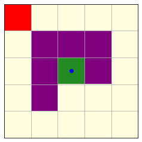

```python
ini_state.plot()
```

We berekenen de zetten die mogelijk zijn vanuit deze begintoestand:

```python
moves = ini_state.calculate_moves()
moves
```

```
[down]
```

We kunnen inderdaad alleen maar naar beneden. Laten we dat doen:

```python
new_state = ini_state.apply_move(moves[0])
new_state
```

```
o....
.###.
.#*#.
.#x..
.....
```

En laten we die nieuwe toestand plotten:

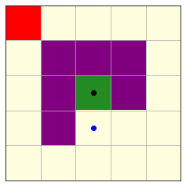

```python
new_state.plot()
```

Wat zijn hier nu de mogelijke zetten?

```python
moves = new_state.calculate_moves()
moves
```

```
[right, down]
```

Laten we naar rechts gaan:

```python
new_state = new_state.apply_move(moves[0])
new_state
```

```
o....
.###.
.#*#.
.#xx.
.....
```

En we maken opnieuw een plot:

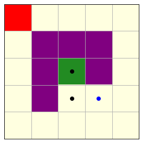

```python
new_state.plot()
```

We kunnen verder gaan tot aan het doel door m.b.v. een `while`-lus in elke nieuwe state de mogelijke zetten te berekenen en dan telkens de eerste zet nemen:

```python
while not new_state.is_goal():
    print(new_state)
    moves = new_state.calculate_moves()
    print(moves)
    print()
    new_state = new_state.apply_move(moves[0])
```

```
o....
.###.
.#*#.
.#xx.
.....
[right, down]

o....
.###.
.#*#.
.#xxx
.....
[up, down]

o....
.###.
.#*#x
.#xxx
.....
[up]

o....
.###x
.#*#x
.#xxx
.....
[up]

o...x
.###x
.#*#x
.#xxx
.....
[left]

o..xx
.###x
.#*#x
.#xxx
.....
[left]

o.xxx
.###x
.#*#x
.#xxx
.....
[left]

oxxxx
.###x
.#*#x
.#xxx
.....
[left]
```

We zijn dus in de eindtoestand gekomen en kunnen die plotten om het afgelegde pad van start tot doel te zien:

```python
new_state.plot()
```

[output not shown]

We kunnen het afleggen van het pad ook "live" visualiseren:

```python
new_state.dynamic_plot()
```

[output not shown]

## Opdrachten

### Opdracht 1

Start opnieuw vanuit de begintoestand, maar neem nu *altijd* de *eerste* zet uit de lijst van mogelijke zetten. Krijg je hetzelfde pad?

```python
state = InitialMazeState(maze)
while not state.is_goal():
    print(state)
    moves = state.calculate_moves()
    print(moves)
    print()
    state = state.apply_move(moves[0])
state.plot()
```

[output not shown]

```
o....
.###.
.#*#.
.#...
.....
[down]

o....
.###.
.#*#.
.#x..
.....
[right, down]

o....
.###.
.#*#.
.#xx.
.....
[right, down]

o....
.###.
.#*#.
.#xxx
.....
[up, down]

o....
.###.
.#*#x
.#xxx
.....
[up]

o....
.###x
.#*#x
.#xxx
.....
```

[output cut: 14 more lines]

```
[left]

o.xxx
.###x
.#*#x
.#xxx
.....
[left]

oxxxx
.###x
.#*#x
.#xxx
.....
[left]
```

### Opdracht 2

Start nog eens vanuit de begintoestand, maar neem nu *altijd* de *laatste* zet uit de lijst van mogelijke zetten. Krijg je een oplossing?

```
o....
.###.
.#*#.
.#...
.....
[down]

o....
.###.
.#*#.
.#x..
.....
[right, down]

o....
.###.
.#*#.
.#x..
..x..
[left, right]

o....
.###.
.#*#.
.#x..
..xx.
[right, up]

o....
.###.
.#*#.
.#xx.
..xx.
[right]

o....
.###.
.#*#.
.#xxx
..xx.
[up, down]

o....
.###.
.#*#.
.#xxx
..xxx
[]

No moves possible!
```

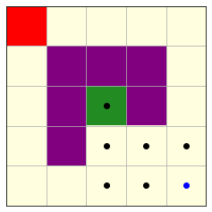

```python
state = InitialMazeState(maze)
while not state.is_goal():
    print(state)
    moves = state.calculate_moves()
    print(moves)
    print()
    try:
        state = state.apply_move(moves[-1])
    except:
        print("No moves possible!")
        break  # niet vergeten uit de lus te "breken"
state.plot()
```

### Opdracht 3

Probeer nu toch eens om het pad naar het doel te volgen dat links van de barrières loopt.

Tip: Je kan de `MazeMove` klassen in een list stoppen, bijv. `[Left, Right, Up, Down]`, en die met een `for`-lus doorlopen.

```
o....
.###.
.#*#.
.#...
.....

o....
.###.
.#*#.
.#x..
.....

o....
.###.
.#*#.
.#x..
..x..

o....
.###.
.#*#.
.#x..
.xx..

o....
.###.
.#*#.
.#x..
xxx..

o....
.###.
.#*#.
x#x..
xxx..

o....
.###.
x#*#.
x#x..
xxx..

o....
x###.
x#*#.
x#x..
xxx..
```

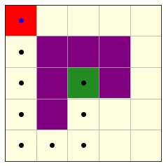

```python
state = InitialMazeState(maze)

for Step in [Down, Down, Left, Left, Up, Up, Up, Up]:
    print(state)
    print()
    state = state.apply_move(Step(state))

state.plot()
```

### Opdracht 4

Implementeer het doolhof uit de figuur aan het begin van deze notebook en volg het kortste pad van start naar doel. Zijn er meerdere mogelijkheden?

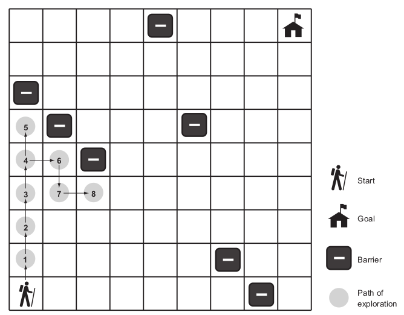

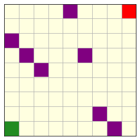

```python
maze = Maze.create(['....#...o',
                    '.........',
                    '#........',
                    '.#...#...',
                    '..#......',
                    '.........',
                    '.........',
                    '......#..',
                    '*......#.'])
maze.plot()
```

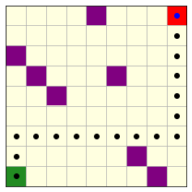

```python
# er zijn uiteraard meerdere mogelijkheden, maar wij kiezen voor de gemakkelijkste :-)
state = InitialMazeState(maze)
for Step in [Up] * 2 + [Right] * (maze.size-1) + [Up] * 6:
    state = state.apply_move(Step(state))
state.plot()
```

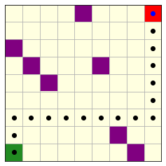

```python
state.dynamic_plot(1)
```

### Opdracht 5

Maak je eigen doolhof met een start- en eindvakje en verschillende barrières. Implementeer verschillende paden van start naar doel. Kan je een algoritme bedenken om altijd een pad van start naar doel te vinden zonder vast te lopen?

### Denkvraag

Neem nu het spel [ganzenbord](https://nl.wikipedia.org/wiki/Ganzenbord). Stel dat we het bord met één pion willen doorlopen van start tot einde. Denk eens na over de state-space representatie:

- Wat zijn de productieregels?
- Hoe definieer je de state?
- Hoe zou je dat implementeren in Python?

De toestand kunnen we hier definiëren aan de hand van de positie, dit is het vakje waar de pion staat, en de configuratie van het bord, hier start- en eindvakje en de vakjes met een put of valkuil waarop de pion terug naar start moet. (We houden het hier eenvoudig, maar uiteraard kan je nog andere speciale vakjes definiëren).

```python
# position is hier een integer die het huidige vakje aangeeft
class Position:

    def __init__(self, number):
        self.number = number

    def __eq__(self, other):
        return self.number == other.number

    def __repr__(self):
        return str(self.number)
```

```python
p = Position(15)
p
```

```
15
```

```python
# path is strikt genomen niet nodig om de toestand te definiëren
# maar is wel handig om bij te houden

import numpy as np

class Path:

    def __init__(self, *positions):
        self.positions = positions

    @property
    def length(self):
        return len(self.positions)

    @property
    def numbers(self):
        return np.array([position.number for position in self.positions])

    def contains(self, position):
        return position in self.positions

    def add(self, position):
        return Path(*self.positions, position)

    def __repr__(self):
        positions = ", ".join([str(position) for position in self.positions])
        return f"[{positions}]"
```

```python
pad = Path(p, Position(17))
pad
```

```
[15, 17]
```

```python
# Tenslotte definiëren we ons bord met putten die een pion terug naar start sturen

class GooseGameBoard:

    def __init__(self, pitfalls=[], start=1, goal=63):
        self.start = start
        self.goal = goal
        self.pitfalls = pitfalls

    def get_start(self):
        return Position(self.start)

    def get_goal(self):
        return Position(self.goal)

    def is_valid(self, position):
        # checkt of een positie geldig is: moet binnen de range van start en goal liggen
        return self.start <= position.number <= self.goal

    def to_dict(self):
        # omzetten naar dictionary kan handig zijn
        # een Python dictionary is equivalent met een Java HashMap
        return dict(start=self.start, goal=self.goal, putten=self.pitfalls)

    def __repr__(self):
        return str(self.to_dict())
```

```python
bord = GooseGameBoard(list(range(10, 63, 10)))
bord
```

```
{'start': 1, 'goal': 63, 'putten': [10, 20, 30, 40, 50, 60]}
```

De production rules zijn alle mogelijke uitkomsten na het werpen van de 2 dobbelstenen. Voor de eenvoud gebruiken we hier 1 dobbelsteen, dus zijn er 6 regels: 1, 2, 3, 4, 5 en 6 vakjes vooruit gaan.

```python
# klasse Throw moet erven van superklasse Move

class Throw(Move):

    def __init__(self, state, steps):
        super().__init__(state)
        self.steps = steps

    def new_position(self):
        return Position(self.state.position.number + self.steps)

    def __repr__(self):
        return "gooi " + str(self.steps)
```

```python
# Ook hier definiëren we een klasse voor elke worp
class Een(Throw):
    def __init__(self, state):
        super().__init__(state, 1)
class Twee(Throw):
    def __init__(self, state):
        super().__init__(state, 2)
class Drie(Throw):
    def __init__(self, state):
        super().__init__(state, 3)
class Vier(Throw):
    def __init__(self, state):
        super().__init__(state, 4)
class Vijf(Throw):
    def __init__(self, state):
        super().__init__(state, 5)
class Zes(Throw):
    def __init__(self, state):
        super().__init__(state, 6)
```

Tenslotte moeten we nog een klasse definiëren voor de toestand.

```python
# klasse GooseGameState moet erven van State

class GooseGameState(State):

    def __init__(self, board, position, path):
        self.board = board
        self.position = position
        self.path = path

    @property
    def full_path(self):
        return self.path.add(self.position)

    def calculate_moves(self):
        if self.is_goal():
            return []  # geen moves meer als we in de eindtoestand zijn
        moves = [Een(self), Twee(self), Drie(self), Vier(self), Vijf(self), Zes(self)]
        return [move for move in moves if self.is_valid(move)]

    def is_valid(self, move):
        return self.board.is_valid(move.new_position())

    def new_position(self, move):
        new_position = move.new_position()
        if new_position.number in self.board.pitfalls:
            return self.board.get_start()  # terug naar start bij put
        if new_position.number > self.board.goal:
            return self.position  # blijven staan als je op 't einde te veel gooit
        return new_position

    def apply_move(self, move):
        return GooseGameState(self.board, self.new_position(move), self.full_path)  # nieuwe toestand

    def is_goal(self):
        return self.board.get_goal() == self.position

    def to_dict(self):
        state = self.board.to_dict()
        state["vakje"] = self.position
        state["vorige"] = self.path
        return state

    def __repr__(self):
        return str(self.to_dict())
```

```python
# klasse voor de initiële toestand
class InitialGooseGameState(GooseGameState):
    def __init__(self, board):
        super().__init__(board, board.get_start(), Path())
```

Even uittesten:

```python
ini_state = InitialGooseGameState(bord)
ini_state
```

```
{'start': 1, 'goal': 63, 'putten': [10, 20, 30, 40, 50, 60], 'vakje': 1, 'vorige': []}
```

```python
moves = ini_state.calculate_moves()  # 6 mogelijke uitkomsten met 1 dobbelsteen
moves
```

```
[gooi 1, gooi 2, gooi 3, gooi 4, gooi 5, gooi 6]
```

```python
new_state = ini_state.apply_move(moves[4])  # we gooien 5 -> vakje 6
new_state
```

```
{'start': 1, 'goal': 63, 'putten': [10, 20, 30, 40, 50, 60], 'vakje': 6, 'vorige': [1]}
```

```python
moves = new_state.calculate_moves()
moves
```

```
[gooi 1, gooi 2, gooi 3, gooi 4, gooi 5, gooi 6]
```

```python
new_state = new_state.apply_move(moves[3])  # we gooien 4 -> terug naar start!
new_state
```

```
{'start': 1, 'goal': 63, 'putten': [10, 20, 30, 40, 50, 60], 'vakje': 1, 'vorige': [1, 6]}
```

We kunnen nu effectief het gooien van een dobbelsteen simuleren door gebruiken te maken van functie `randint` uit module `rand`:

```python
from random import randint, seed

seed(0)  # we definiëren een seed voor de random number generator zodat we altijd dezelfde uitkomst krijgen
state = InitialGooseGameState(bord)
n = 0
while not state.is_goal() and n < 100:  # we definiëren voor de zekerheid een maximum aantal worpen
    worp = Throw(state, steps=randint(1, 6))
    state = state.apply_move(worp)
    n += 1

print("aantal worpen:", n)
print(state)
```

```
aantal worpen: 49
{'start': 1, 'goal': 63, 'putten': [10, 20, 30, 40, 50, 60], 'vakje': 63, 'vorige': [1, 5, 9, 1, 4, 9, 13, 17, 1, 5, 8, 13, 15, 1, 3, 6, 8, 9, 14, 17, 22, 28, 33, 35, 38, 39, 45, 46, 52, 55, 59, 59, 1, 4, 8, 11, 16, 22, 24, 29, 33, 37, 42, 45, 46, 51, 52, 53, 59]}
```

```python
# aantal worpen is inderdaad gelijk aan de lengte van ons pad (dat het laatste vakje niet bevat!)
state.path.length
```

```
49
```